# Factors Affecting Borrower APR

## by Maryam Adamu Bala

## Investigation Overview

This investigation will look at the features that could affect the APR of borrowers. The main focus is on the **original loan amount, ProsperRating (Alpha) and Loan Term.**

## Dataset Overview

This dataset contains 113,937 loans with 81 variables on each loan, including loan amount, borrower rate (or interest rate), current loan status, borrower income, and many others.The dataset can be found [here](https://s3.amazonaws.com/udacity-hosted-downloads/ud651/prosperLoanData.csv) with feature documentation available [here](https://docs.google.com/spreadsheets/d/1gDyi_L4UvIrLTEC6Wri5nbaMmkGmLQBk-Yx3z0XDEtI/edit#gid=0)

## Borrower APR

The distribution of the Borrower APR is multimodal. A small peak centered at 0.09, a large peak centered at 0.18. There is also a small peak centered 0.29 and a high peak between 0.35 and 0.36. Very few people have an APR greater than 0.4. A high APR means that you will be paying a higher interest rate on any money you borrow.

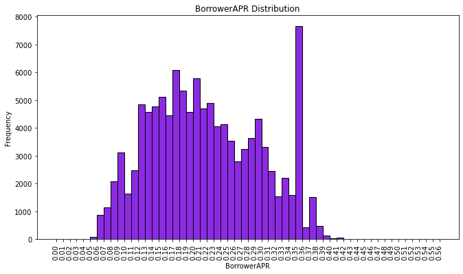

## Original Loan Amount

The highest frequencies are at 4k, followed by 15k and 10k. There are other high spikes at 2k and 5K

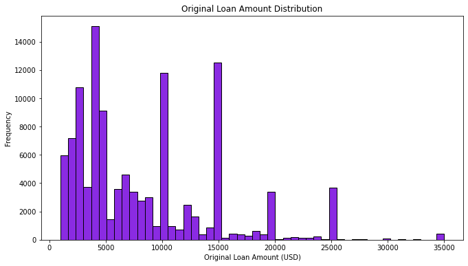

## ProsperRating (Alpha)

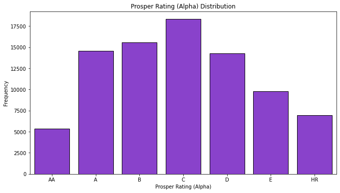

## Borrower APR and Original Loan Amount

The borrower APR decreases with increased loan amount

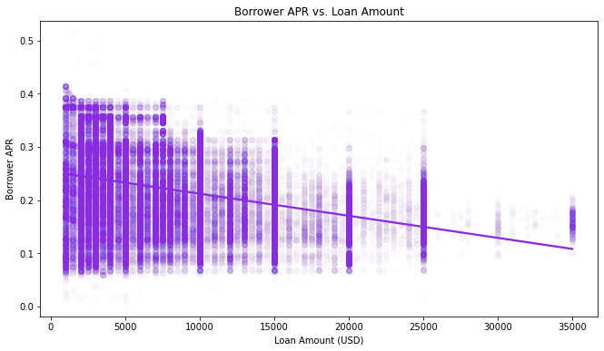

## Borrower APR by Loan Term and Alpha Rating

- For AA-B ratings, the APR increases with the increased of loan term.
- The APR decreases with the increased of loan term for C - HR ratings.

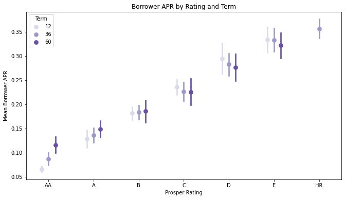